# Pilgrim Bank Case Study

Mason Hansen

1/22/2019

Analysis of meaningfulness

- Business issue –Identification of core challenge
  - What is the business related assumption to be evaluated (Online usage impact on profitability)
- Statistical issue –Transformation of challenge to statistical test
  - How to transform business assumption to a statistical test (e.g. testable hypothesis)
- Statistical test
  - Selection -What specific statistical test is needed
  - Organization -What data extract to use, what software to use, how to setup data in software,
  - Execution -How to select/run the statistical analysis
- Statistical Result
  - Result interpretation –what is the statistical answer to the hypothesis test
- Business Conclusion
  - Business interpretation –What business conclusion can be drawn from the statistical answer

Case Formulation (Introduction) Q1. Based on the sample, what does customer profitability look like for the entire population?

- descriptive Statistics will be analyzed for customer profitability in order to gain better insight on potential variables that might have influence customer profitability for Pilgrim Bank in the year 1999. Q2. Challenge: Is online banking a beneficial channel that increases profitability or does it detract from profitability?
- Hypothesis:
- H<sub>0</sub>: The average value of profitability for online banking and non-online banking customers is the same $(\mu~Online~ = \mu~NonOnline~)$
- H<sub>a</sub>: The average value of profitability for online banking and non_online banking customers is not equal $(\mu~online~ \neq \mu~non-online~)$

Q3. What Role do Customer Demographics play in online versus offline customers?

- Statistical tests
  - A Student’s t-Test will be utilized to test the difference in mean profitability values between customers who use the online banking channel versus customers that do not use the online banking channel.
  - A linear regression model will be applied to investigate customer demographics and their impact on customer profitability for the year 1999
  - Odds ratios, calculated from the linear model will be investigated to highlight the influence of customer demographic variables on overall customer profitability

## Data Clean Up

The data set is not entirely complete, including missing values in ~25% of the sample variables age and income. In order to account for missing values for proper analysis, deletion of ~25% of a sample is too aggressive. For this analysis, a dynamic method of imputation was chosen as the accurate replacement of missing values. The method use is called K-nearest_neighbors imputation (KNN). This method was chosen because all of the missing values were either age or income, which were previously binned into ranges of values. Since both age and income are now represented as categorical variables, the precision of a central tendency imputation of either the median or mean would seem inadequate. KNN is an algorithm that classifies each data point based on every independent variable in the data set (profit, age, income, tenure, district, online) and measures the distance from each data point to the central value (mean) of each cluster. For example, if person A and person B have similar profit, income and tenure, but only person A is missing their Age. The algorithm will calculate the distance between person A and person B, and filling in the missing value with the value of the “nearest neighbor”. In this scenario, person B is nearest to person A, so the missing age of person A will be imputed with person B’s age value. This algorithm can handle continuous, categorical and binary data, which is the main reason why this method was chosen.

### Descriptive Statistics

To better visualizle the data, a series of boxplots were plotted. Including each of variables Online, Age, Bill Pay and Income plotted against Profit. The variable District has been excluded from the visualization.

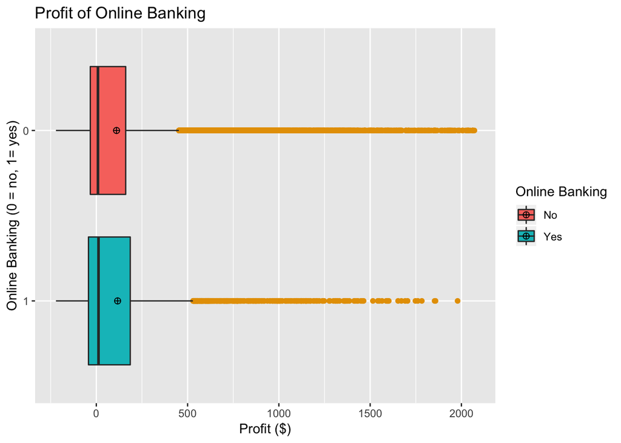

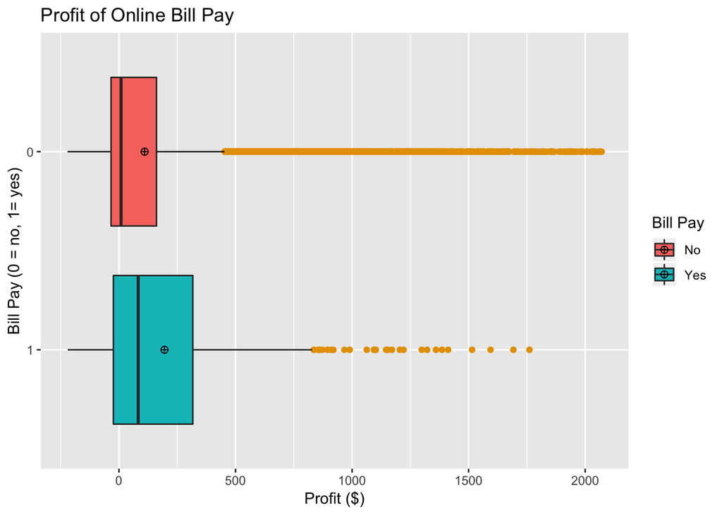

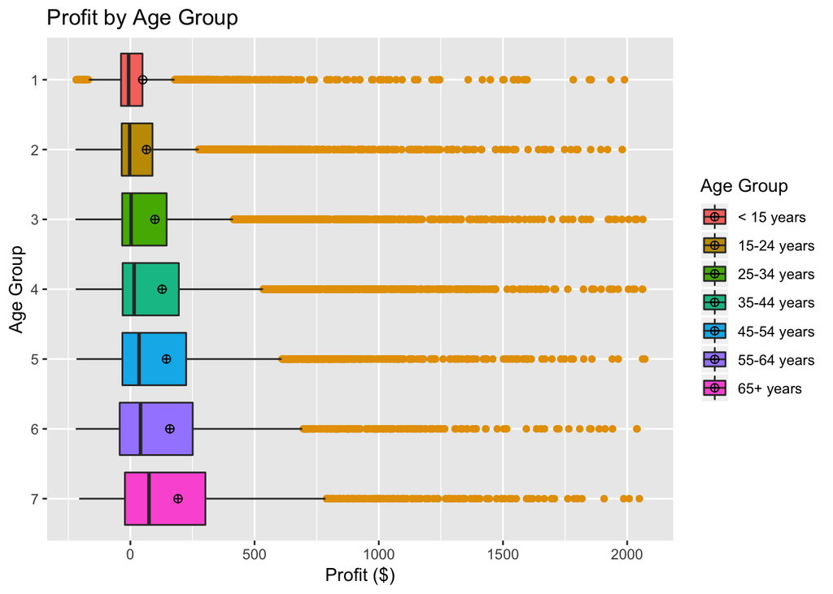

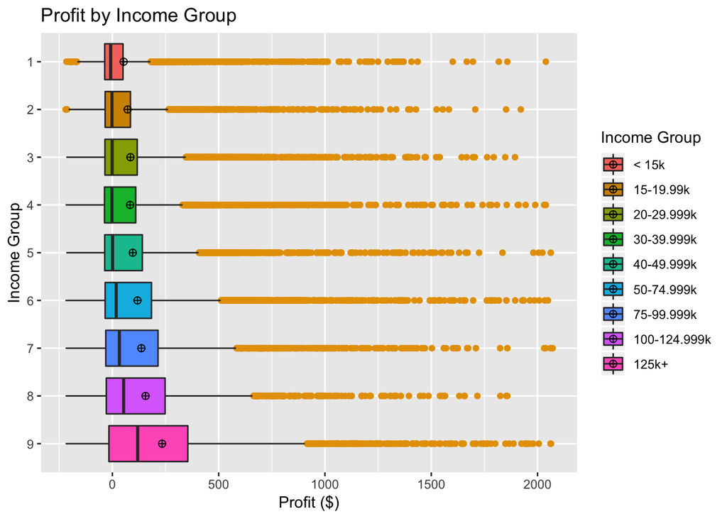

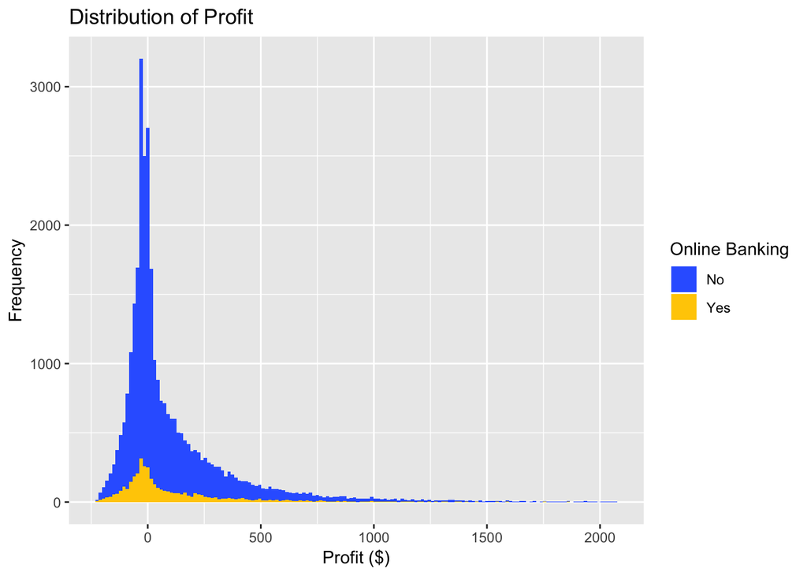

### t-tests for Profit

```
Welch Two Sample t-test
```

data: pilgrim_new$X9Profit by pilgrim_new$X9Online t = -1.2124, df = 4882.1, p-value = 0.2254 alternative hypothesis: true difference in means is not equal to 0 95 percent confidence interval: -15.389887 3.628706 sample estimates: mean in group 0 mean in group 1 110.7862 116.6668

### Linear Regression

|  | Estimate | Std. Error | t value | Pr(>\|t\|) |
| --- | --- | --- | --- | --- |
| **(Intercept)** | -27.2 | 8.09 | -3.36 | 0.000786 |
| **X9Billpay1** | 78.4 | 12.3 | 6.35 | 2.24e-10 |
| **X9District1200** | 17.7 | 5.12 | 3.45 | 0.00056 |
| **X9District1300** | 7.02 | 6.26 | 1.12 | 0.262 |
| **X9Inc2** | 18.4 | 7.46 | 2.46 | 0.0138 |
| **X9Inc3** | 26.3 | 6.18 | 4.26 | 2.09e-05 |
| **X9Inc4** | 24.2 | 6.19 | 3.92 | 8.98e-05 |
| **X9Inc5** | 36.1 | 6.42 | 5.62 | 1.96e-08 |
| **X9Inc6** | 49.9 | 5.9 | 8.46 | 2.89e-17 |
| **X9Inc7** | 68.1 | 6.68 | 10.2 | 2.34e-24 |
| **X9Inc8** | 85 | 7.96 | 10.7 | 1.33e-26 |
| **X9Inc9** | 155 | 6.99 | 22.2 | 9.14e-109 |
| **X9Online1** | 0.863 | 4.89 | 0.176 | 0.86 |
| **X9Tenure** | 4.77 | 0.191 | 24.9 | 1.08e-135 |
| **X9Age2** | 4.16 | 6.3 | 0.66 | 0.509 |
| **X9Age3** | 19.8 | 6.26 | 3.16 | 0.00155 |
| **X9Age4** | 27.7 | 6.52 | 4.25 | 2.18e-05 |
| **X9Age5** | 35 | 7.19 | 4.87 | 1.13e-06 |
| **X9Age6** | 49.9 | 7.87 | 6.33 | 2.45e-10 |
| **X9Age7** | 84.5 | 7.68 | 11 | 3.89e-28 |